# ¡Cuidado con el paro femenino!

Authors

Gema Fernández-Avilés (Gema.FAviles@uclm.es)

Isidro Hidalgo (Isidro.Hidalgo@uclm.es)

Published

**Note**

Los datos que se utilizan en esta historia están disponibles en el paquete `CDR` que puede instalarse con el siguiente comando (se comprueba si no lo está):

**Instalación y/o carga del paquete `CDR`**

```r
if (!require(CDR)){
  if (!require(remotes)) {install.packages("remotes")}
  remotes::install_github("cdr-book/CDR")
  }
```

Los datos referentes a la evolución del paro en Castilla-La Mancha se encuentran en el objeto `parados_clm`.

# 1 Entender el contexto:

**Cómo definir el propósito y la audiencia de tu análisis**

En los últimos 15 años el mundo ha sufrido dos grandes periodos de **crisis económica**: en **2008**, de tipo financiero; y en **2020**, a causa de la pandemia de **COVID-19**. La Directora del Instituto de la Mujer de Castilla-La Mancha quiere que mi equipo analice el impacto de ambas crisis en las mujeres de la región.

Hemos conseguido del paquete `CDR` un conjunto de datos con algunas variables interesantes: **sexo** y **edad** del parado, **tiempo de búsqueda de empleo** y **sector de procedencia**. El conjunto de datos utilizado comprende la **media anual del paro registrado en la comunidad autónoma de Castilla-La Mancha** desagregado según estas variables, a lo largo de los años que van desde 2007 a 2022.

**Configuración inicial y datos**

```r
library(CDR)
library(tidyverse)
library(summarytools)
library(explore)
library(ggpubr)
library(ggridges)

paleta_heatmaps <- c("#B3FF0080", "#213894FF")
paleta_lineas <- c("blue4", "orange", "darkgreen")

data("parados_clm")
head(parados_clm)
```

```
# A tibble: 6 × 8
  anyo  sexo    edad sector t_bus_e   tramo_edad t_bus_e_agr parados
  <ord> <fct>  <dbl> <fct>  <ord>     <ord>      <ord>         <dbl>
1 2007  hombre    16 agricu t<=7 días <30 años   t<=6 meses    0.667
2 2018  mujer     36 sinact t<=7 días 30-44 años t<=6 meses    1.67
3 2012  mujer     30 agricu t<=7 días 30-44 años t<=6 meses    5.33
4 2022  mujer     49 constr t<=7 días >44 años   t<=6 meses    0.75
5 2007  mujer     54 indust t<=7 días >44 años   t<=6 meses    1.5
6 2008  mujer     29 servic t<=7 días <30 años   t<=6 meses   58.1
```

**Configuración inicial y datos**

```r
help(parados_clm)

# Siempre debemos echar un vistazo rápido a los datos:
summary(parados_clm)
```

```
      anyo           sexo            edad          sector
 2010   : 5805   hombre:46153   Min.   :16.00   agricu:18421
 2013   : 5805   mujer :46062   1st Qu.:28.00   constr:18233
 2011   : 5804                  Median :40.00   indust:18417
 2012   : 5804                  Mean   :40.41   servic:18611
 2014   : 5785                  3rd Qu.:52.00   sinact:18533
 2021   : 5773                  Max.   :64.00
 (Other):57439
          t_bus_e           tramo_edad            t_bus_e_agr
 1<t<=3 meses : 7832   <30 años  :25158   t<=6 meses    :39079
 15<t<=30 días: 7824   30-44 años:30650   6<t<=12 meses :15567
 3<t<=6 meses : 7823   >44 años  :36407   12<t<=24 meses:30158
 t<=7 días    : 7804                      t>24 meses    : 7411
 6<t<=9 meses : 7804
 7<t<=15 días : 7796
 (Other)      :45332
    parados
 Min.   :   0.0833
 1st Qu.:   3.8333
 Median :  10.8333
 Mean   :  32.5927
 3rd Qu.:  31.3333
 Max.   :1285.1667
```

**Configuración inicial y datos**

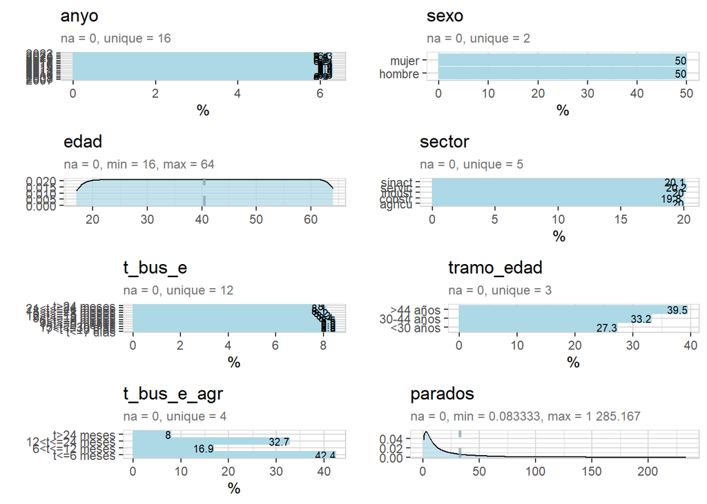

```r
parados_clm |> explore_all()
```

# 2 Elegir una visualización adecuada

**Selección de gráficos y visualizaciones que mejor representen tus datos.**

## 2.1 Impacto de las crisis en la evolución global del paro

Podemos construir un gráfico lineal para empezar viendo la evolución…

**Resumen de los parados por años objetivo**

```r
resumen <- parados_clm |>
  group_by(anyo) |>
  summarise(parados = sum(parados)) |>
  mutate(anyo = as.numeric(as.character(anyo)))
anyos <- c(2007, 2013, 2019, 2020, 2022)
paro_anyos <- resumen |>
  filter(anyo %in% anyos) |>
  select(parados) |>
  mutate(parados = round(parados, 0))
puntos <- data.frame(anyos, paro_anyos)
```

**Creación del gráfico lineal**

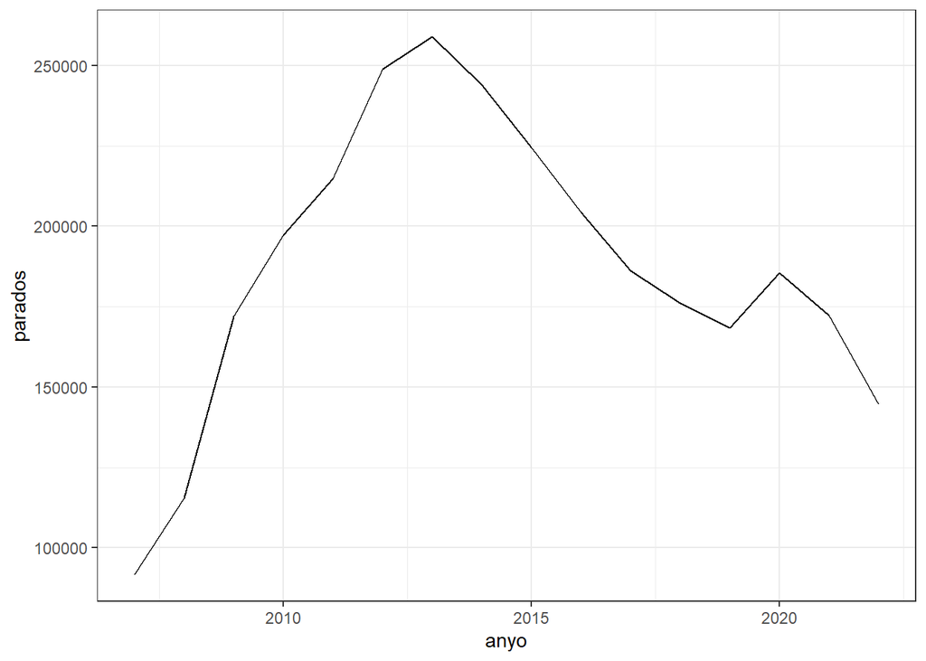

```r
ggplot(resumen, aes(anyo, parados)) +
  geom_line()+
  theme_bw()
```

El gráfico no tiene una escala de ordenadas realista (la variación queda algo exagerada porque el eje `y` no empieza en `0`), y es muy simple. No tiene título… Vamos a mejorarlo un poco…

**Creación del gráfico lineal mejorado**

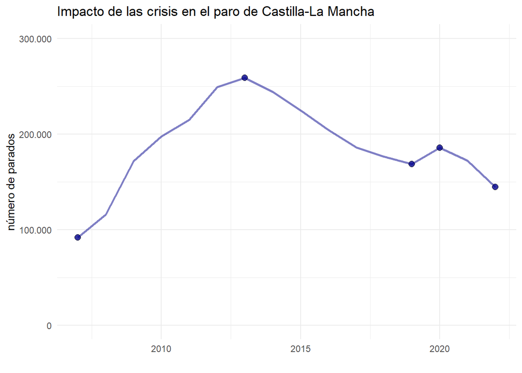

```r
graf <- ggplot(resumen, aes(anyo, parados)) +
  geom_line(linewidth = 1, col = paleta_lineas[1], alpha = 0.5) +
  xlab("") +
  ylab("número de parados") +
  geom_point(puntos,
    mapping = aes(x = anyos, y = parados),
    shape = "circle filled", size = 2.5, fill = paleta_lineas[1],
    alpha = 0.8
  ) +
  scale_y_continuous(
    labels = function(x) {
      format(x,
        big.mark = ".",
        decimal.mark = ",", scientific = FALSE
      )
    },
    limits = c(0, 300000)
  ) +
  ggtitle("Impacto de las crisis en el paro de Castilla-La Mancha") +
  theme_minimal()

graf
```

En adelante, vamos a tomar como puntos de referencia los años previos a las crisis: 2007 y 2019, y el último año de datos, 2022. Se puede observar que la crisis de la **COVID-19** aumentó el paro en 2020, pero la **crisis de 2008** tuvo un impacto enorme y generalizado en toda la economía, por lo que su efecto en el paro registrado fue mucho mayor, multiplicándolo casi por 3.

# 3 Eliminar el desorden. Enfocar la atención

Vale, está bien la evolución general, pero trabajamos para el Instituto de la mujer… ¡hay que separar por sexo!:

**Resumen por sexo**

```r
resumen_sexo <- parados_clm |>
  group_by(anyo, sexo) |>
  summarise(parados = sum(parados)) |>
  mutate(anyo = as.numeric(as.character(anyo)))
paro_anyos <- resumen_sexo |>
  filter(anyo %in% anyos) |>
  select(sexo, parados) |>
  mutate(parados = round(parados, 0))
puntos <- data.frame(
  anyos = rep(anyos, each = 2),
  sexo = paro_anyos$sexo,
  parados = paro_anyos$parados
)
```

**Gráfico de lineas por sexo**

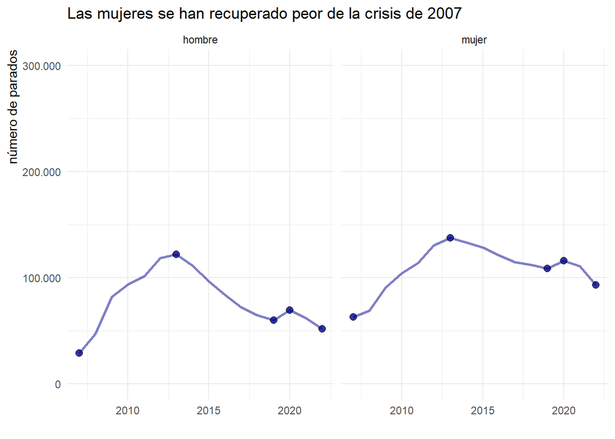

```r
graf <- ggplot(resumen_sexo, aes(anyo, parados)) +
  geom_line(linewidth = 1, col = paleta_lineas[1], alpha = 0.5) +
  xlab("") +
  ylab("número de parados") +
  facet_wrap("sexo") +
  geom_point(puntos,
    mapping = aes(x = anyos, y = parados),
    shape = "circle filled", size = 2.5, fill = paleta_lineas[1],
    alpha = 0.8
  ) +
  scale_y_continuous(
    labels = function(x) {
      format(x,
        big.mark = ".",
        decimal.mark = ",", scientific = FALSE
      )
    },
    limits = c(0, 300000)
  ) +
  ggtitle("Las mujeres se han recuperado peor de la crisis de 2007") +
  theme_minimal() +
  theme(axis.title.y = element_text(hjust = 1))

graf
```

**Simplificación de gráficos eliminando elementos innecesarios.**

¿Lo podemos hacer mejor?: sí, uniendo los gráficos, para mejorar la comparación, añadiendo color y otros formatos…

**Gráfico de lineas por sexo mejorado**

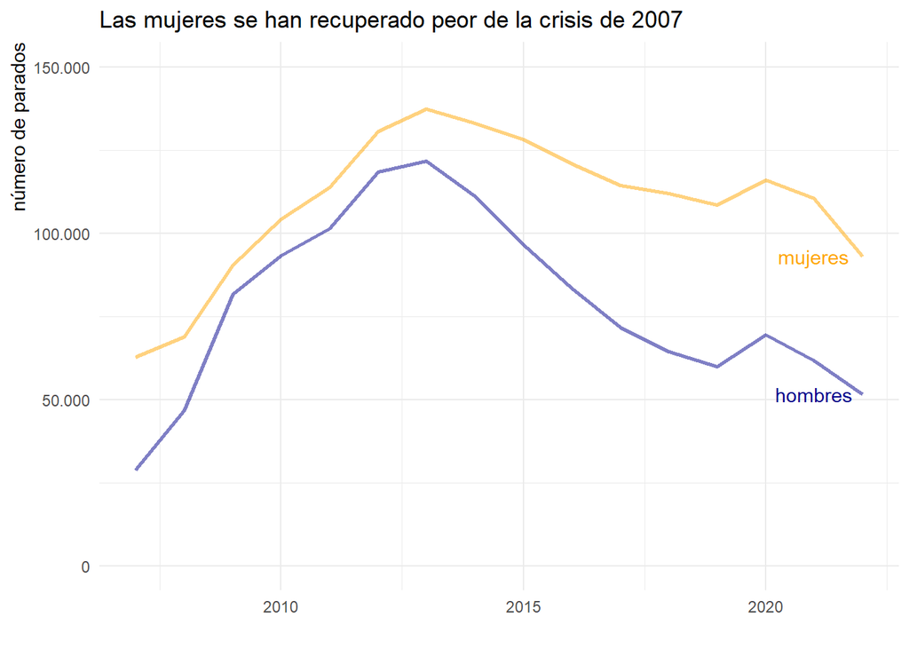

```r
graf <- ggplot(resumen_sexo, aes(anyo, parados)) +
  geom_line(
    data = resumen_sexo[resumen_sexo$sexo == "hombre", ],
    linewidth = 1, col = paleta_lineas[1], alpha = 0.5
  ) +
  geom_line(
    data = resumen_sexo[resumen_sexo$sexo == "mujer", ],
    linewidth = 1, col = paleta_lineas[2], alpha = 0.5
  ) +
  xlab("") +
  ylab("número de parados") +
  annotate(
    geom = "text", label = "hombres", col = paleta_lineas[1],
    x = 2021,
    y = puntos$parados[puntos$sexo == "hombre" &
      puntos$anyos == 2022]
  ) +
  annotate(
    geom = "text", label = "mujeres", col = paleta_lineas[2],
    x = 2021,
    y = puntos$parados[puntos$sexo == "mujer" &
      puntos$anyos == 2022]
  ) +
  scale_y_continuous(
    labels = function(x) {
      format(x,
        big.mark = ".",
        decimal.mark = ",", scientific = FALSE
      )
    },
    limits = c(0, 150000)
  ) +
  ggtitle("Las mujeres se han recuperado peor de la crisis de 2007") +
  theme_minimal() +
  theme(axis.title.y = element_text(hjust = 1))

graf
```

En este caso, como ya habíamos marcado los puntos de giro en el gráfico del paro total, hemos preferido quitarlos, porque no nos gustan estéticamente, pero aprovechamos el último punto para colocar la etiqueta de la serie, mucho mejor que en una leyenda… ¡y más visible!

## 3.1 Evolución del paro medio anual en función de la edad y el sexo

Para ver simultáneamente una variable cuantitativa en función de otras dos variables, podemos usar un mapa de calor:

**Preparación de los datos. Selección de variables y años**

```r
tabla <- parados_clm |>
  select(anyo, sexo, edad, parados) |>
  filter(anyo %in% c(2007, 2019, 2022))
tabla <- tabla |>
  group_by(anyo, sexo, edad) |>
  summarise(parados = sum(parados))
```

**Heatmap por sexo, edad y año**

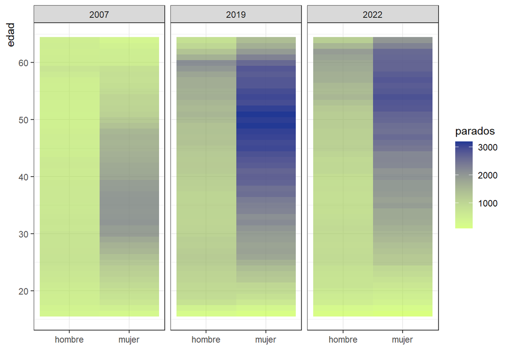

```r
graf <- ggplot(tabla, aes(x = sexo, y = edad, fill = parados)) +
  geom_raster() +
  scale_fill_gradientn(colours = paleta_heatmaps) +
  facet_wrap(~anyo) +
  labs(x = "", y = "edad") +
  theme_bw() +
  theme(axis.title.y = element_text(hjust = 1))

graf
```

Se puede apreciar que en los dos procesos críticos se ha producido un **desplazamiento del paro hacia los intervalos de mayor edad**, especialmente en las **mujeres**.

El mapa de calor es muy útil para una primera impresión, pero ¿es la mejor visualización? Si nos fijamos, no se aprecia bien la forma de la distribución. Vamos a intentar mejorar el resultado:

**Gráfico de paneles por sexo, edad y año**

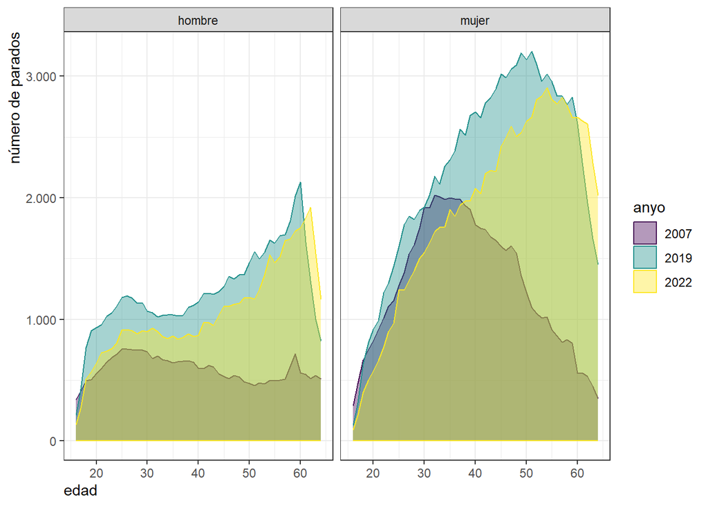

```r
ggplot(tabla, aes(
  x = edad, y = parados,
  col = anyo, fill = anyo
)) +
  geom_ribbon(aes(ymin = 0, ymax = tabla$parados), alpha = 0.4) +
  facet_wrap(~sexo, ncol = 2) +
  ylab("número de parados") +
  scale_y_continuous(labels = function(x) {
    format(x,
      big.mark = ".", decimal.mark = ",", scientific = FALSE
    )
  }) +
  theme_bw() +
  theme(axis.title.x = element_text(hjust = 0),
        axis.title.y = element_text(hjust = 1))
```

Ahora se ve mucho mejor que en 2007, antes de ambas crisis, los parados presentan **dos máximos**, en torno a 25 y 60 años, mientras que las desempleadas tienen una distribución bastante centrada entre 30 y 40 años. En cambio, en 2019 y aún más en 2022 se aprecia el desplazamiento de la distribución de los parados de ambos sexos hacia los estratos de edad **mayores de 50 años**. Este desplazamiento es algo más intenso en las mujeres.

**Tip**

¿Qué técnicas hemos usado para destacar los puntos clave en nuestras visualizaciones?: - Los formatos. - Colocación de los textos (etiquetas de los ejes). - La elegancia de la sencillez… ¡permite resaltar lo importante!

## 3.2 Evolución del paro femenino según el tiempo de búsqueda de empleo

Hacemos lo mismo que con el sexo, pero incluimos la variable `t_bus_e_agr` (tiempo de búsqueda de empleo):

**Preparación de los datos. Selección de variables y años**

```r
tabla <- parados_clm |>
  filter(anyo %in% c(2007, 2019, 2022)) |>
  select(anyo, sexo, t_bus_e_agr, edad, parados)
tabla <- tabla |>
  group_by(anyo, t_bus_e_agr, edad, sexo) |>
  summarise(parados = sum(parados))
```

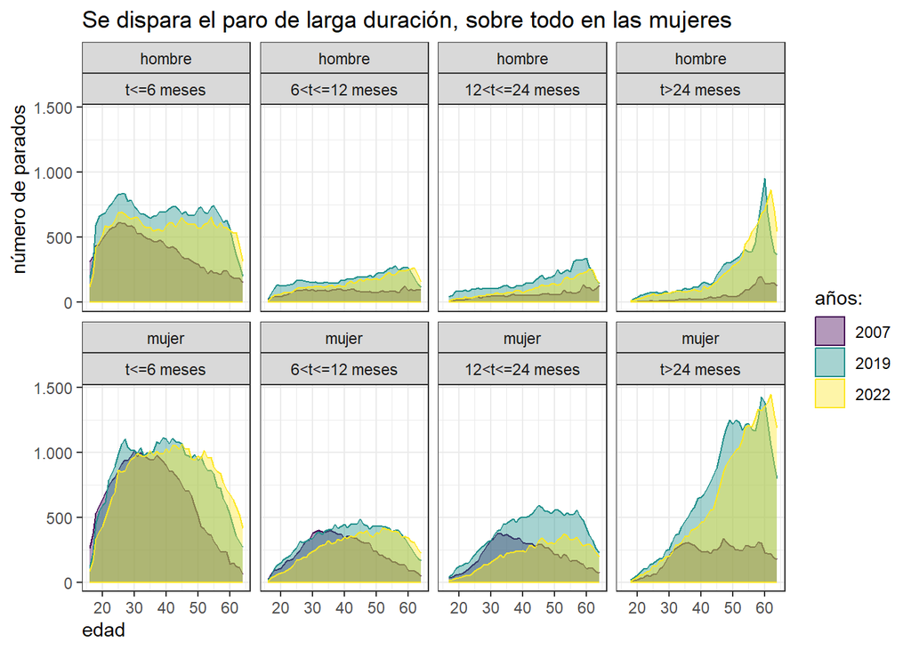

```r
ggplot(tabla, aes(
  x = edad, y = parados,
  col = anyo, fill = anyo
)) +
  geom_ribbon(aes(ymin = 0, ymax = tabla$parados), alpha = 0.4) +
  facet_wrap(~ sexo * t_bus_e_agr, ncol = 4) +
  ylab("número de parados") +
  labs(fill = "años:", color = "años:") +
  scale_y_continuous(labels = function(x) {
    format(x,
      big.mark = ".", decimal.mark = ",", scientific = FALSE
    )
  }) +
  ggtitle("Se dispara el paro de larga duración, sobre todo en las mujeres") +
  theme_bw() +
  theme(axis.title.x = element_text(hjust = 0),
        axis.title.y = element_text(hjust = 1))
```

Se aprecia claramente que el tramo con mayor incremento de número de parados es el correspondiente a más de 24 meses de búsqueda de empleo (**paro de muy larga duración**), ya que la crisis financiera de 2008 les redujo su probabilidad de encontrar empleo. Se puede afirmar también que los dos períodos de crisis han provocado la creación de un **paro estructural de larga duración, y de más edad**. Este efecto es mayor en las mujeres.

## 3.3 Evolución del paro femenino según el sector de procedencia

Si repetimos el gráfico según el sector de procedencia, tenemos:

**Preparación de datos. Selección de variables y años**

```r
tabla <- parados_clm |>
  filter(anyo %in% c(2007, 2019, 2022)) |>
  select(anyo, sexo, sector, edad, parados)
tabla <- tabla |>
  group_by(anyo, sector, edad, sexo) |>
  summarise(parados = sum(parados))
```

**Gráfico de facetas por sexo, sector, edad y año**

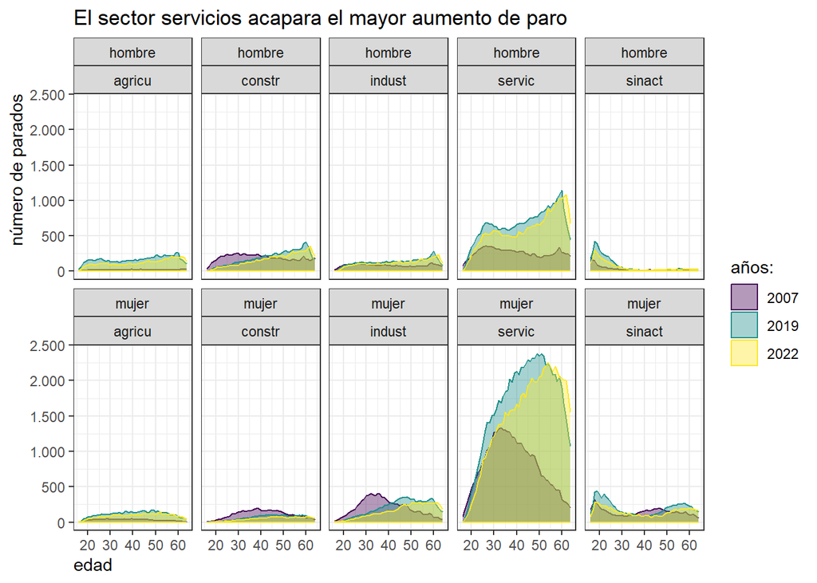

```r
ggplot(tabla, aes(
  x = edad, y = parados,
  col = anyo, fill = anyo
)) +
  geom_ribbon(aes(ymin = 0, ymax = tabla$parados), alpha = 0.4) +
  facet_wrap(~ sexo * sector, ncol = 5) +
  ylab("número de parados") +
  labs(fill = "años:", color = "años:") +
  scale_y_continuous(labels = function(x) {
    format(x,
      big.mark = ".", decimal.mark = ",", scientific = FALSE
    )
  }) +
  ggtitle("El sector servicios acapara el mayor aumento de paro") +
  theme_bw() +
  theme(axis.title.x = element_text(hjust = 0),
        axis.title.y = element_text(hjust = 1))
```

# 4 Contar una historia

**Cómo narrar una historia convincente con tus datos.**

Hasta ahora hemos visto el **planteamiento**, en el que proporcionamos el contexto: trabajamos para el Instituto de la Mujer de Castilla-La Mancha, nos interesa el paro femenino especialmente, por razones obvias…

El análisis exploratorio de las variables, de forma aislada o combinada, nos introduce en la **trama**, donde descubrimos aspectos interesantes de nuestros datos: las mujeres se han recuperado peor, especialmente en el sector servicios. También hemos visto como el conjunto del paro ha envejecido…

## 4.1 Para pensar:

En este caso, estamos haciendo visualización para un alto cargo de la JCCM, capaz de interpretar los gráficos. ¿Usaríamos los mismos gráficos para una charla de la Directora del Instituto de la Mujer a la población en general?